# Clase 3: Ejercicios — Solución

Francisco Tamayo

1ro de julio de 2026

```r
library(tidyverse)
library(broom)
```

```r
macro <- read_csv("/Users/franciscotamayo/Desktop/R/fred_macro.csv") %>%
  mutate(fecha = as.Date(fecha))
```

# Parte 1 — Limpieza y preparación

**Ejercicio 1.** Conteo de `NA` por columna.

```r
macro %>%
  summarise(across(everything(), ~ sum(is.na(.))))
```

```
## # A tibble: 1 × 4
##   fecha desempleo inflacion tasa_interes
##   <int>     <int>     <int>        <int>
## 1     0         0         0            0
```

**Ejercicio 2.** Rezagos y dummy de crisis.

```r
macro <- macro %>%
  mutate(
    tasa_lag1     = lag(tasa_interes, 1),
    desempleo_lag1 = lag(desempleo, 1),
    crisis        = desempleo > 7.5
  )
```

**Ejercicio 3.** Subset 2008–2012.

```r
crisis_financiera <- macro %>%
  filter(year(fecha) >= 2008, year(fecha) <= 2012)

nrow(crisis_financiera)
```

```
## [1] 60
```

# Parte 2 — Exploración visual

**Ejercicio 4.** Tres series en paneles separados.

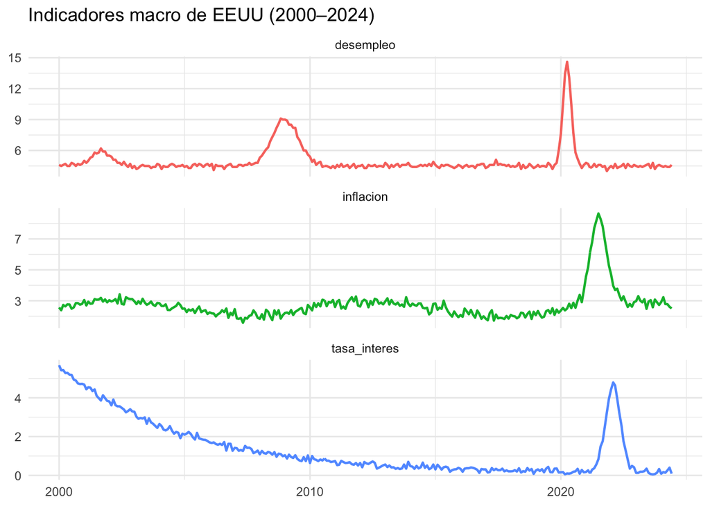

```r
macro %>%
  select(fecha, desempleo, inflacion, tasa_interes) %>%
  pivot_longer(-fecha, names_to = "serie", values_to = "valor") %>%
  ggplot(aes(x = fecha, y = valor, color = serie)) +
  geom_line(linewidth = 0.8) +
  facet_wrap(~ serie, scales = "free_y", ncol = 1) +
  labs(title = "Indicadores macro de EEUU (2000–2024)",
       x = NULL, y = NULL) +
  theme_minimal() +
  theme(legend.position = "none")
```

**Ejercicio 5.** Dispersión desempleo vs tasa de interés, por crisis.

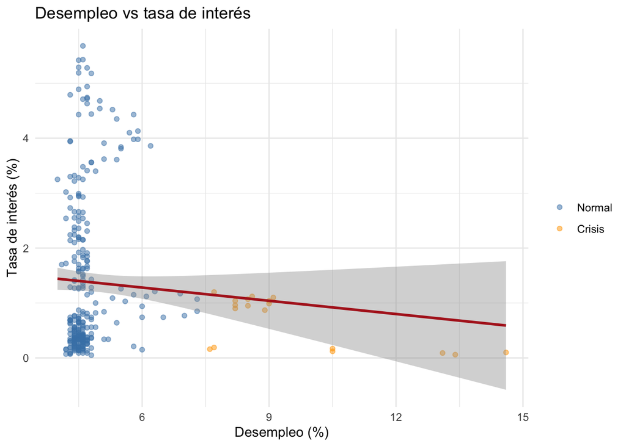

```r
macro %>%
  ggplot(aes(x = desempleo, y = tasa_interes, color = crisis)) +
  geom_point(alpha = 0.5) +
  geom_smooth(method = "lm", se = TRUE, color = "firebrick") +
  scale_color_manual(values = c("FALSE" = "steelblue", "TRUE" = "orange"),
                     labels = c("Normal", "Crisis")) +
  labs(title = "Desempleo vs tasa de interés",
       x = "Desempleo (%)", y = "Tasa de interés (%)",
       color = NULL) +
  theme_minimal()
```

> *Interpretación:* la pendiente de la recta es **negativa**: a mayor desempleo, menor tasa de interés. Es decir, la FED baja las tasas para estimular la economía cuando hay más desempleo. Los puntos naranjas (crisis) se concentran en la esquina de alto desempleo y baja tasa, el cual es coherente con el escenario 2008–2009.

# Parte 3 — Regresión simple

**Ejercicio 6.** Regresión simple.

```r
modelo_simple <- lm(tasa_interes ~ inflacion, data = macro)
modelo_simple
```

```
##
## Call:
## lm(formula = tasa_interes ~ inflacion, data = macro)
##
## Coefficients:
## (Intercept)    inflacion
##      0.8042       0.2040
```

**Ejercicio 7.** Resumen e interpretación.

```r
summary(modelo_simple)
```

```
##
## Call:
## lm(formula = tasa_interes ~ inflacion, data = macro)
##
## Residuals:
##     Min      1Q  Median      3Q     Max
## -2.0050 -0.9716 -0.6673  0.6008  4.3515
##
## Coefficients:
##             Estimate Std. Error t value Pr(>|t|)
## (Intercept)  0.80425    0.24401   3.296   0.0011 **
## inflacion    0.20399    0.08379   2.434   0.0155 *
## ---
## Signif. codes:  0 '***' 0.001 '**' 0.01 '*' 0.05 '.' 0.1 ' ' 1
##
## Residual standard error: 1.409 on 292 degrees of freedom
## Multiple R-squared:  0.01989,    Adjusted R-squared:  0.01654
## F-statistic: 5.927 on 1 and 292 DF,  p-value: 0.01551
```

# Parte 4 — Regresión múltiple

**Ejercicio 8.** Tres modelos anidados.

```r
m1 <- lm(tasa_interes ~ desempleo,                       data = macro)
m2 <- lm(tasa_interes ~ desempleo + inflacion,           data = macro)
m3 <- lm(tasa_interes ~ desempleo + inflacion + tasa_lag1, data = macro)
```

**Ejercicio 9.** Comparación con `glance()` + `bind_rows()`.

```r
list(m1, m2, m3) %>%
  map(glance) %>%
  bind_rows(.id = "modelo") %>%
  select(modelo, r.squared, adj.r.squared, AIC, BIC)
```

```
## # A tibble: 3 × 5
##   modelo r.squared adj.r.squared   AIC   BIC
##   <chr>      <dbl>         <dbl> <dbl> <dbl>
## 1 1        0.00586       0.00246 1044. 1055.
## 2 2        0.0236        0.0168  1041. 1056.
## 3 3        0.983         0.983   -154. -136.
```

> *Interpretación:* el modelo con más variables (“m3”) tiene el R^2 ajustado más alto y el AIC más bajo. Esto indica que tanto la inflación como la tasa de interés rezagada aportan información explicativa más allá del desempleo solo.

**Ejercicio 10.** Coeficientes del mejor modelo, filtrados a p-value < 0.05.

```r
m3 %>%
  tidy() %>%
  filter(p.value < 0.05)
```

```
## # A tibble: 3 × 5
##   term        estimate std.error statistic   p.value
##   <chr>          <dbl>     <dbl>     <dbl>     <dbl>
## 1 (Intercept)  -0.150    0.0547      -2.74 6.48e-  3
## 2 inflacion     0.0590   0.0111       5.32 2.03e-  7
## 3 tasa_lag1     0.972    0.00764    127.   8.51e-256
```

# Parte 5 — Diagnósticos

**Ejercicio 11.** Residuales vs valores ajustados de “m3”.

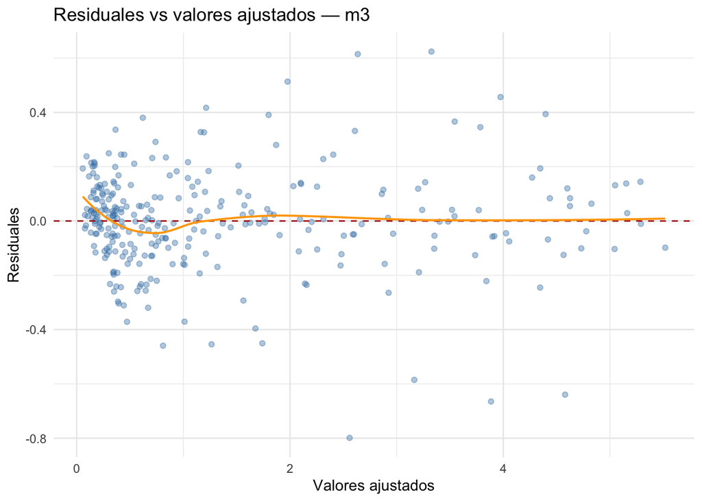

```r
augment(m3) %>%
  ggplot(aes(x = .fitted, y = .resid)) +
  geom_point(alpha = 0.4, color = "steelblue") +
  geom_hline(yintercept = 0, linetype = "dashed", color = "firebrick") +
  geom_smooth(se = FALSE, color = "orange", linewidth = 0.7) +
  labs(title = "Residuales vs valores ajustados — m3",
       x = "Valores ajustados", y = "Residuales") +
  theme_minimal()
```

> *Interpretación:* si la línea naranja de tendencia se aleja del cero o muestra curvatura (U, parábola), hay estructura no capturada por el modelo. Idealmente debe oscilar pegada al cero.

**Ejercicio 12.** Residuales en el tiempo. Se eliminan primero los `NA` introducidos por `lag()`.

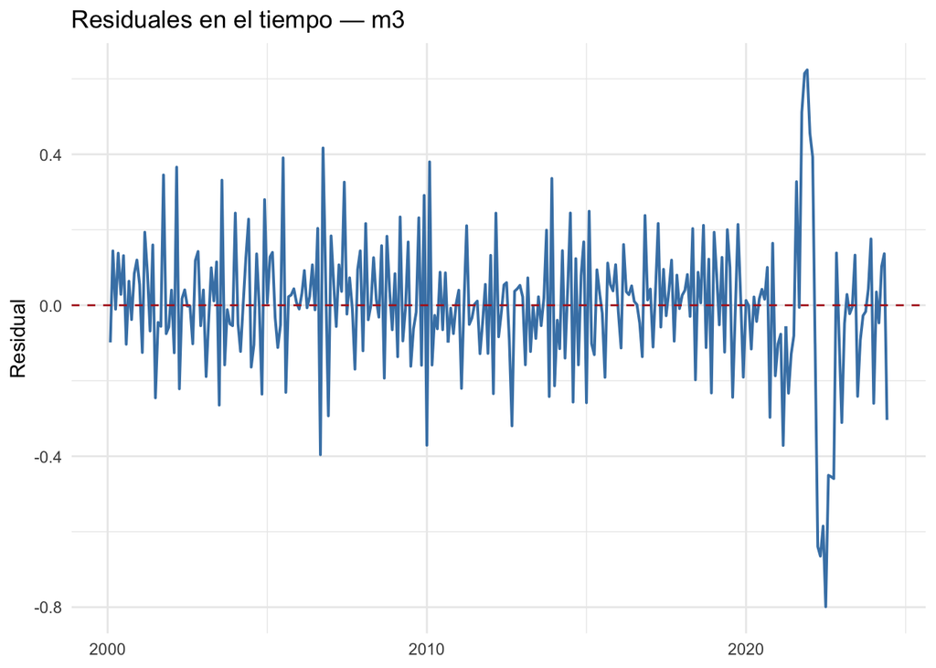

```r
macro_sin_na <- macro %>% drop_na(tasa_lag1)

m3 <- lm(tasa_interes ~ desempleo + inflacion + tasa_lag1,
         data = macro_sin_na)

augment(m3, data = macro_sin_na) %>%
  ggplot(aes(x = fecha, y = .resid)) +
  geom_line(color = "steelblue", linewidth = 0.7) +
  geom_hline(yintercept = 0, linetype = "dashed", color = "firebrick") +
  labs(title = "Residuales en el tiempo — m3",
       x = NULL, y = "Residual") +
  theme_minimal()
```

> *Interpretación:* si los residuales muestran racimos del mismo signo durante varios meses consecutivos, es decir, oleadas positivas seguidas de oleadas negativas. Por lo tanto, hay autocorrelación serial, lo que invalida los errores estándar y los p-values de “m3”.

# Parte 6 — Período de crisis

**Ejercicio 13.** Modelo solo durante 2008–2012.

```r
m3_crisis <- lm(tasa_interes ~ desempleo + inflacion + tasa_lag1,
                data = crisis_financiera)

comparacion <- bind_rows(
  tidy(m3)         %>% mutate(modelo = "Completo (2000–2024)"),
  tidy(m3_crisis)  %>% mutate(modelo = "Crisis (2008–2012)")
) %>%
  select(modelo, term, estimate, std.error, p.value)

comparacion
```

```
## # A tibble: 8 × 5
##   modelo               term        estimate std.error   p.value
##   <chr>                <chr>          <dbl>     <dbl>     <dbl>
## 1 Completo (2000–2024) (Intercept) -0.150     0.0547  6.48e-  3
## 2 Completo (2000–2024) desempleo    0.00152   0.00801 8.50e-  1
## 3 Completo (2000–2024) inflacion    0.0590    0.0111  2.03e-  7
## 4 Completo (2000–2024) tasa_lag1    0.972     0.00764 8.51e-256
## 5 Crisis (2008–2012)   (Intercept)  0.705     0.284   1.61e-  2
## 6 Crisis (2008–2012)   desempleo    0.0175    0.0159  2.76e-  1
## 7 Crisis (2008–2012)   inflacion   -0.157     0.0725  3.41e-  2
## 8 Crisis (2008–2012)   tasa_lag1    0.496     0.116   7.07e-  5
```